# Cervera_Rosell_Marc_PAC1_IPYNB

[2] --> *draw* [en línia] [consulta: 18 d'octubre de 2025]. Disponible a https://networkx.org/documentation/stable/reference/generated/networkx.drawing.nx_pylab.draw.html **--> Documentació de la funció per a dibuixar el graf base.**

[3] --> *Graph.copy* [en línia] [consulta: 21 d'octubre de 2025]. Disponible a: https://networkx.org/documentation/stable/reference/classes/generated/networkx.Graph.copy.html **--> Documentació de la funció per a crear una còpia d'un graf.**

[4] --> *Graph.nodes* [en línia] [consulta: 18 d'octubre de 2025]. Disponible a: https://networkx.org/documentation/stable/reference/classes/generated/networkx.Graph.nodes.html#networkx.Graph.nodes **--> Documentació de la funció per a obtenir tots els nodes del graf base.**

[5] --> *Graph.edges* [en línia] [consulta: 18 d'octubre de 2025]. Disponible a: https://networkx.org/documentation/stable/reference/classes/generated/networkx.Graph.edges.html#networkx.Graph.edges **--> Documentació de la funció per a obtenir totes les arestes del graf base.**

[6] --> *Modelo Watts-Strogatz* [en línia] [consulta: 18 d'octubre de 2025]. Disponible a: https://academia-lab.com/enciclopedia/modelo-watts-strogatz/ **--> Web utilizada per obtenir un enunciat més clar de l'algorisme de *rewiring* i confirmar el funcionament d'aquest després de llegir el capitol 3 del llibre.**

[7] --> *Python | Visualize graphs generated in NetworkX using Matplotlib* [en línia] [consulta: 18 d'octubre de 2025]. Disponible a: https://www.geeksforgeeks.org/python/python-visualize-graphs-generated-in-networkx-using-matplotlib/ **--> Web utilitzada per ampliar la informació en el moment de dibuixar el graf.**

[8] --> *MultiDiGraph.has_edge* [en línia] [consulta: 18 d'octubre de 2025]. Disponible a: https://networkx.org/documentation/stable/reference/classes/generated/networkx.MultiDiGraph.has_edge.html **--> Documentació de la funció per a saber si existeix una aresta entre dos nodes.** **--> aquesta comprovació ha estat eliminada del codi.**

[9] --> *Python Random random() Method* [en línia] [consulta: 18 d'octubre de 2025]. Disponible a: https://www.w3schools.com/python/ref_random_random.asp **--> Documentació de la funció per a generar nombres aleatoris de tipus float.**

[10] --> *Generate Random Float numbers in Python using random() and Uniform()* [en línia] [consulta: 18 d'octubre de 2025]. Disponible a: https://pynative.com/python-get-random-float-numbers/ **--> Web utilitzada per cercar informació sobre nombres aleatoris de tipus float.**

[11] --> *random — Generate pseudo-random numbers* [en línia] [consulta: 18 d'octubre de 2025]. Disponible a: https://docs.python.org/3/library/random.html#random.uniform **--> Documentació de la llibreria *random*.**

[12] --> *Graph.remove_edge* [en línia] [consulta: 19 d'octubre de 2025]. Disponible a: https://networkx.org/documentation/stable/reference/classes/generated/networkx.Graph.remove_edge.html **--> Documentació de la funció per a eliminar una aresta entre dos nodes.**

[13] --> *Python Random choice() Method* [en línia] [consulta: 19 d'octubre de 2025]. Disponible a: https://www.w3schools.com/python/ref_random_choice.asp **--> Documentació de la funció per a fer una selecció aleatòria d'una seqüència.**

[14] --> *Graph.add_edge* [en línia] [consulta: 19 d'octubre de 2025]. Disponible a: https://networkx.org/documentation/stable/reference/classes/generated/networkx.Graph.add_edge.html **--> Documentació de la funció per a afegir una aresta entre dos nodes.**

[15] --> *ChatGPT* [en línia] [consulta: 19 d'octubre de 2025]. Disponible a: https://chatgpt.com/ **--> Eina d'IA generativa utilitzada per solucionar un error en el calcul de *new_possible_connections*: *TypeError: unsupported operand type(s) for -: 'NodeView' and 'method'*.**

**També utilitzat per solucionar l'error en el moment de calcular *new_node*: *TypeError: 'set' object is not subscriptable*.**

**També utilitzada per saber com posar dues linies en un mateix grafic i quina es la funció per a un gràfic de linies.**

**També utilitzat per obtenir informació dels warnings: *RuntimeWarning: invalid value encountered in divide bin_means_x = (np.histogram(keys, bins, weights=keys)[0] / np.histogram(keys, bins)[0]) # Bibliografia: [46] i [15]* i *RuntimeWarning: invalid value encountered in divide bin_means_y = (np.histogram(keys, bins, weights=vals)[0] / np.histogram(keys, bins)[0]) # Bibliografia: [46] i [15]***

**També utilitzat per saber com convertir un string que conté un diccionari a un diccionari.**

**També utilitzat per saber com fer que el graf no es mogués. (exercici 3)**

[16] --> *matplotlib.pyplot.figure* [en línia] [consulta: 19 d'octubre de 2025]. Disponible a: https://matplotlib.org/stable/api/_as_gen/matplotlib.pyplot.figure.html **--> Documentació de la funció per crear una nova figura. Revisada pel paràmetre figsize.**

[17] --> *Tight layout guide* [en línia] [consulta: 19 d'octubre de 2025]. Disponible a: https://matplotlib.org/stable/users/explain/axes/tight_layout_guide.html **--> Documentació de la funció *tight_layout()* per a ajustar una figura a la mida marcada.**

[19] --> *average_shortest_path_length* [en línia] [consulta: 20 d'octubre de 2025]. Disponible a: https://networkx.org/documentation/stable/reference/algorithms/generated/networkx.algorithms.shortest_paths.generic.average_shortest_path_length.html#networkx.algorithms.shortest_paths.generic.average_shortest_path_length **--> Documentació de la funció per a obtenir la mitjana del camí mes curt d'un graf.**

[20] --> *average_clustering* [en línia] [consulta: 20 d'octubre de 2025]. Disponible a: https://networkx.org/documentation/stable/reference/algorithms/generated/networkx.algorithms.cluster.average_clustering.html#networkx.algorithms.cluster.average_clustering **--> Documentació de la funció per a obtenir el coeficient de clustering mitjà d'un graf.**

[21] --> *numpy.mean* [en línia] [consulta: 20 d'octubre de 2025]. Disponible a: https://numpy.org/doc/2.2/reference/generated/numpy.mean.html **--> Documentació de la funció per a la mitjana aritmètica.**

[22] --> *Google Gemini* [en línia] [consulta: 20 d'octubre de 2025]. Disponible a: https://gemini.google.com/app?hl=es-ES **--> Eina d'IA generativa utilitzada per obtenir informació sobre tècniques de normalització.**

**També utilitzat per saber si le model de Barabási-Albert permet multiconnexió de nodes y *self-loops* (Exercici 2).**

**També utilitzat per fer més eficient el codi que crea les arestes del graf de l'oracle de Bacon en l'exercici 3.**

**També utilitzat per saber com calcular L en un graf no connex. (Exercici 3)**

[23] --> *Plot line graph from NumPy array* [en línia] [consulta: 20 d'octubre de 2025]. Disponible a: https://www.geeksforgeeks.org/python/plot-line-graph-from-numpy-array/ **--> Web usada per saber com posar noms als eixos i titol al gràfic.**

[24] --> *matplotlib.pyplot.plot* [en línia] [consulta: 20 d'octubre de 2025]. Disponible a: https://matplotlib.org/stable/api/_as_gen/matplotlib.pyplot.plot.html **--> Documentació oficial de la funció per a dibuixar un gràfic de linies. Revisada pels paràmetres *color* i *label*.**

[25] --> *matplotlib.pyplot.legend* [en línia] [consulta: 20 d'octubre de 2025]. Disponible a: https://matplotlib.org/stable/api/_as_gen/matplotlib.pyplot.legend.html **--> Documentació oficial de la funció per a afegir una llegenda.**

**Exercici 2: Xarxes de món petit segons el model de preferential attachment de Barabási** (3 punts)

Existeixen diversos models de creixement i dinàmica de xarxes. El model de preferential attachment de Barabási també és un model dinàmic molt popular. Pots llegir-ne més a: https://networksciencebook.com/chapter/5#growth

Es demana:

- Implementa l'algoritme de preferential attachment de Barabási (no utilitzis una llibreria) (0.5p)
- Representa una figura com la figura 5.3 utilitzant aquest model de creixement de https://networksciencebook.com/chapter/5#growth (1p)
- Representa la figura 5.4 de https://networksciencebook.com/chapter/5#growth (1.5p)

**Solució**

```python
import random as rnd
# Bibliografia: [27]
# m = Nombre de noves connexions
# final_graph_nodes = Nombre de nodes amb finals --> Condicio per parar l'algorisme
def barabasi_albert_preferential_attachement(graph, m, final_graph_nodes):
    final_graph = graph.copy() # Bibliografia: [3]
    initial_nodes = len(list(graph.nodes()))
    for i in range(initial_nodes, final_graph_nodes):
        node_degrees = dict(final_graph.degree()) # Diciconari {node: grau} # Bibliografia: [28]
        connections_of_new_node = rnd.choices(list(node_degrees.keys()), weights=list(node_degrees.values()), k=m) # Bibliografia: [29] i [30]
        # weights = possibilitat per cada node. k = llarg de la llista reotrn
        final_graph.add_node(len(list(nx.nodes(final_graph)))) # len(list(nx.graph(nodes))) - Nom node = següent nombre # Bibliografia: [31] i [32]
        for node in connections_of_new_node:
            final_graph.add_edge(node, i)
    return final_graph
```

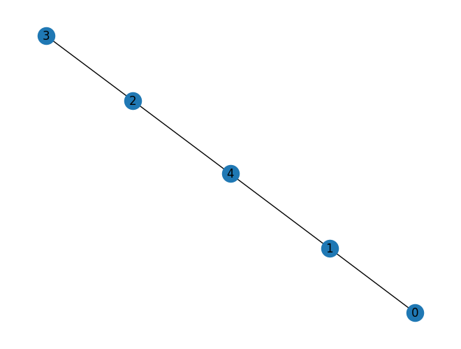

```python
# Graf base per a crear la imatge 5.3
base_graph = nx.Graph()
base_graph.add_nodes_from(range(5))# Bibliografia: [33]
while not nx.is_connected(base_graph): # Bibliografia: [34]
    node1 = rnd.randint(0, 4) # Bibliografia: [35]
    node2 = rnd.randint(0, 4) # Bibliografia: [35]
    base_graph.add_edge(node1, node2)

plt.figure()
nx.draw(base_graph, with_labels=True)
plt.show()
```

```python
evolution = [] # Llista per a guardar els diferents grafs. Guardara l'evolucio desde el graf base fins al graf final
evolution.append(base_graph) # El primer es el graf base

for i in range(6, 15):
    #graph_barabasi = base_graph
    graph_barabasi = barabasi_albert_preferential_attachement(base_graph, 3, i)
    evolution.append(graph_barabasi)
```

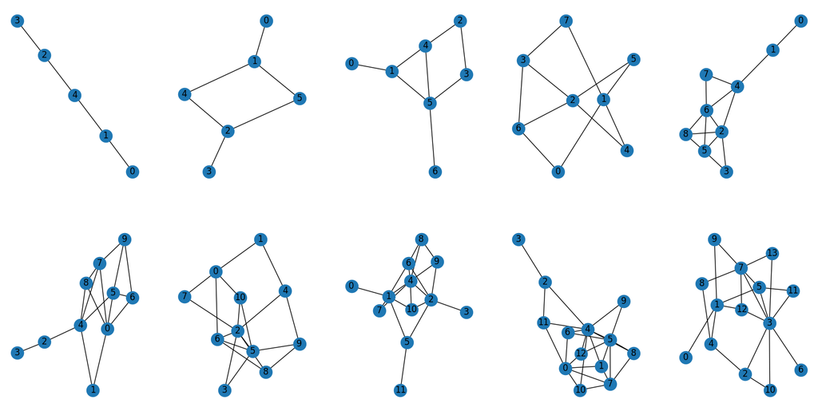

```python
plt.figure()
fig, ax = plt.subplots(2, 5, figsize=(20,10)) # Bibliografia: [36]
k = 0
for i in range(2):
    for j in range(5):
        nx.draw(evolution[k], with_labels=True, ax=ax[i, j]) # Bibliografia: [2]
        k += 1
plt.show()
```

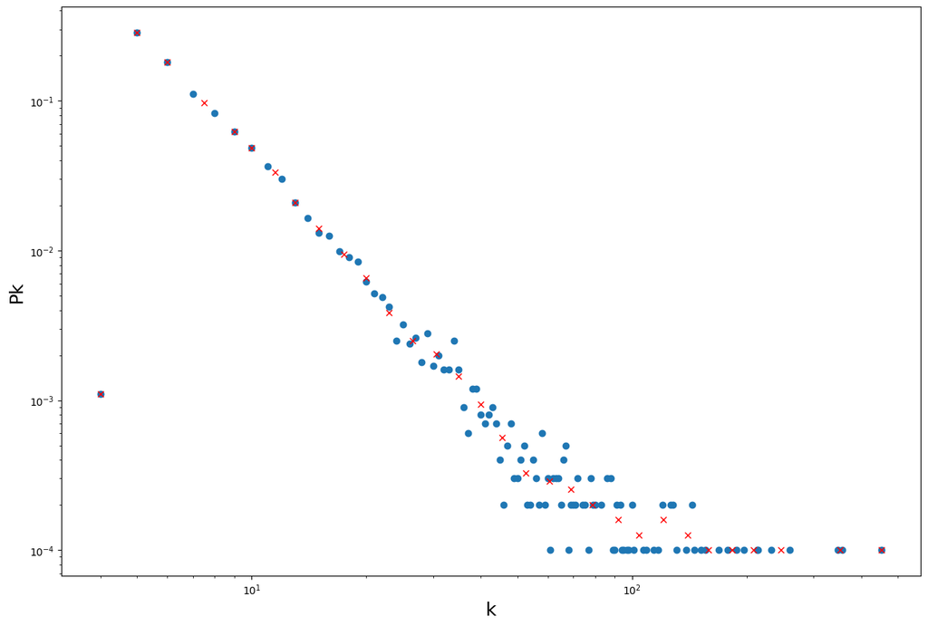

```python
# Construcció imatge 5.4
random_graph = nx.Graph()
random_graph.add_nodes_from(range(5))# Bibliografia: [33]
while not nx.is_connected(random_graph): # Bibliografia: [34]
    node1 = rnd.randint(0, 4) # Bibliografia: [35]
    node2 = rnd.randint(0, 4) # Bibliografia: [35]
    random_graph.add_edge(node1, node2)

m = 5
final_nodes = 10000
final_graph = barabasi_albert_preferential_attachement(random_graph, m, final_nodes)
# --- Trobar probabilitats de cada grau i grafic ----- # Bibliografia: [37]
degrees_mapping = final_graph.degree() # Mapping node: grau # Bibliografia: [38]
degrees_list = list(dict(degrees_mapping).values()) # Llista de graus --> Casos possibles
degrees_cardinality = {} # Mapping grau d'un node: nombre de vegades que existeix el grau en el graf (casos favorables)
for num in degrees_list:
    if num in degrees_cardinality.keys():
        degrees_cardinality[num] += 1
    else:
        degrees_cardinality[num] = 1
possible_cases = len(degrees_list) # Total de casos possibles
probabilities = {} # grau d'un node: probabilitat
for i in degrees_cardinality.keys():
    probabilities[i] = degrees_cardinality[i] / possible_cases

# ----- Log-Binning ----- # Bibliografia: [41] i [42]
max_x = np.log10(max(probabilities.keys())) # Bibliografia: [43]
max_y = np.log10(max(probabilities.values())) # Bibliografia: [43]
max_base = max([max_x, max_y])
min_x = np.log10(min([key for key in probabilities.keys() if key!=0])) # Bibliografia: [43]
bins = np.logspace(min_x, max_base, num=35) # Bibliografia: [44]
keys = np.array(list(probabilities.keys())) # Bibliografia: [45]
vals = np.array(list(probabilities.values())) # Bibliografia: [45]
bin_means_x = (np.histogram(keys, bins, weights=keys)[0] / np.histogram(keys, bins)[0]) # Bibliografia: [46] i [15]
bin_means_y = (np.histogram(keys, bins, weights=vals)[0] / np.histogram(keys, bins)[0]) # Bibliografia: [46] i [15]

plt.figure(figsize=(15,10))
plt.loglog(probabilities.keys(), probabilities.values(), 'o') # Bibliografia: [37] i [39]
plt.loglog(bin_means_x, bin_means_y, 'x', color='red') # Bibliografia: [47]
plt.ylabel("Pk", fontsize=18) # Bibliografia: [40]
plt.xlabel("k", fontsize=18) # Bibliografia: [40]
plt.show()
```

**Referències externes**

[26] --> *complete_graph* [en línia] [consulta: 20 d'octubre de 2025]. Disponible a: https://networkx.org/documentation/stable/reference/generated/networkx.generators.classic.complete_graph.html **--> Documentació de la funció per a crear un graf.**

[27] --> *Modelo Barabási–Albert* [en línia] [consulta: 20 d'octubre de 2025]. Disponible a: https://es.wikipedia.org/wiki/Modelo_Barab%C3%A1si%E2%80%93Albert **--> Utilitzat per obtenir un enunciat formal de l'algorisme.**

[28] --> *Graph.degree* [en línia] [consulta: 20 d'octubre de 2025]. Disponible a: https://networkx.org/documentation/stable/reference/classes/generated/networkx.Graph.degree.html **--> Documentació de la funció per a obtenir el grau dels nodes d'un graf.**

[29] --> *Python Random choices() Method* [en línia] [consulta: 20 d'octubre de 2025]. Disponible a: https://www.w3schools.com/python/ref_random_choices.asp **--> Documentació de la funció per a escollir un nombre k d'elements d'una seqüència.**

[30] --> *Python - random.choices() method* [en línia] [consulta: 20 d'octubre de 2025]. Disponible a: https://www.geeksforgeeks.org/python/random-choices-method-in-python/ **--> Documentació de la funció per a escollir un nombre k d'elements d'una seqüència.**

[31] --> *Creating a graph* [en línia] [consulta: 20 d'octubre de 2025]. Disponible a: https://pelegm-networkx.readthedocs.io/en/latest/tutorial/tutorial.html **--> Tutorial per a crear un graf.**

[32] --> *Graph.add_node* [en línia] [consulta: 20 d'octubre de 2025]. Disponible a: https://networkx.org/documentation/stable/reference/classes/generated/networkx.Graph.add_node.html **--> Documentació de la funció per a afegir un node a un graf.**

[33] --> *Graph.add_nodes_from* [en línia] [consulta: 21 d'octubre de 2025]. Disponible a: https://networkx.org/documentation/stable/reference/classes/generated/networkx.Graph.add_nodes_from.html **--> Documentació de la funció per a afegir múltiples nodes a un graf.**

[34] --> *is_connected* [en línia] [consulta: 21 d'octubre de 2025]. Disponible a: https://networkx.org/documentation/stable/reference/algorithms/generated/networkx.algorithms.components.is_connected.html **--> Documentació de la funció per saber si un graf es connex.**

[35] --> *Python Random randint() Method* [en línia] [consulta: 21 d'octubre de 2025]. Disponible a: https://www.w3schools.com/python/ref_random_randint.asp **--> Documentació de la funció per a generar enters de manera aleatòria.**

[36] --> *Create multiple subplots using plt.subplots* [en línia] [consulta: 21 d'octubre de 2025]. Disponible a: https://matplotlib.org/stable/gallery/subplots_axes_and_figures/subplots_demo.html **--> Documentació de la funció per a crear una figura amb un nombre x de subfigures.**

[37] --> *Plotting the degree distribution of a graph using nx.degree_histogram* [en línia] [consulta: 21 d'octubre de 2025]. Disponible a: https://stackoverflow.com/questions/53958700/plotting-the-degree-distribution-of-a-graph-using-nx-degree-histogram **--> Conversa de StackOverflow usada per obtenir una idea de com crear el gràfic de la distribució de graus.**

[38] --> *Graph.degree* [en línia] [consulta: 21 d'octubre de 2025]. Disponible a: https://networkx.org/documentation/stable/reference/classes/generated/networkx.Graph.degree.html **--> Documentació de la funció per a obtenir un DegreeView que fa un mapping de cada node amb el seu grau.**

[39] --> *matplotlib.pyplot.loglog* [en línia] [consulta: 21 d'octubre de 2025]. Disponible a: https://matplotlib.org/stable/api/_as_gen/matplotlib.pyplot.loglog.html **--> Documentació de la funció per a crear un grafic amb escala logaritmica.**

[40] --> *How do I set the figure title and axes labels font size?* [en línia] [consulta: 21 d'octubre de 2025]. Disponible a: https://stackoverflow.com/questions/12444716/how-do-i-set-the-figure-title-and-axes-labels-font-size **--> Conversa de StackOverflow usada per saber com modificar les etiquetes i la mida de la lletra dels eixos x i y.**

[41] --> *Plotting log-binned network degree distributions* [en línia] [consulta: 21 d'octubre de 2025]. Disponible a: https://stackoverflow.com/questions/16489655/plotting-log-binned-network-degree-distributions **--> Conversa de StackOverflow usada per trobar una mostra de com codificar el log-binning.**

[42] --> *Log binning distribution using python networkx* [en línia] [consulta: 21 d'octubre de 2025]. Disponible a: https://stackoverflow.com/questions/65026937/log-binning-distribution-using-python-networkx **--> Conversa de StackOverflow usada per trobar una mostra de com codificar el log-binning.**

[43] --> *numpy.log10* [en línia] [consulta: 21 d'octubre de 2025]. Disponible a: https://numpy.org/doc/2.1/reference/generated/numpy.log10.html **--> Documentació de la funció per a obtenir el logaritme en base 10 d'un element.**

[44] --> *numpy.logspace* [en línia] [consulta: 21 d'octubre de 2025]. Disponible a: https://numpy.org/doc/2.0/reference/generated/numpy.logspace.html **--> Documentació de la funció per a crear nombres separats de manera uniforme en escala logarítmica.**

[45] --> *numpy.array* [en línia] [consulta: 21 d'octubre de 2025]. Disponible a: https://numpy.org/doc/stable/reference/generated/numpy.array.html **--> Documentació de la funció per crear una array.**

[46] --> *NumPy.histogram() Method in Python* [en línia] [consulta: 21 d'octubre de 2025]. Disponible a: https://www.geeksforgeeks.org/python/numpy-histogram-method-in-python/ **--> Documentació de la funció per crear un histograma.**

[47] --> *Log-Log Plots in Matplotlib* [en línia] [consulta: 21 d'octubre de 2025]. Disponible a: https://pythonguides.com/matplotlib-log-log-plot/ **--> Web que ensenya com utilitzar els *loglog plots*. Revisat per saber com cambiar el color de una marca.**

**Exercici 3: Valors de xarxes reals** (3 punts)

Es demana:

- Reproduir la **taula 3.2: Statistics of small world networks** del llibre *6 graus de separació* de Duncan J. Watts. Per fer-ho, cal obtenir les dades de manera lliure. Adjunteu a l'entrega l'arxiu de dades emprat per tal de poder reproduir la solució. (2,25 punts)
  - No cal calcular ni incloure la fila de "movie actors" d’aquesta taula.
- (a) Discutir els resultats obtinguts en un màxim de dues línies, comparant-los amb el que es menciona al capítol 3 del llibre i, a més, (b) respondre sobre cadascuna de les xarxes anteriors el següent: (0,25 punts)
  - Es tracta d’un graf dirigit o no dirigit? Per què? (màxim dues línies)
  - Es tracta d’un graf ponderat o no ponderat? Per què? (màxim dues línies)
- Realitzar una representació d’alguna de les xarxes anteriorment calculades (power grid o C. elegans). Aquesta representació ha d’estar *treballada*, i es recomana utilitzar alguna biblioteca de representacions dinàmiques de xarxes com pyvis, plotly, bokeh, etc. (0,5 punts)

**------------------------------------------------------------------------------- Part Power Grid -------------------------------------------------------------------------------**

**Dades extretes de --> *Power Grid edgelist* [en línia] [consulta: 22 d'octubre de 2025]. Disponible a: https://www.kaggle.com/datasets/techbashexe/power-grid-edgelist**

```python
edges_power_grid = []
with open("powergrid.edgelist.txt") as f:
    for line in f:
        splitted_data = line.strip().split("\t") # Bibliografia: [48] [49]
        edges_power_grid.append((splitted_data[0], splitted_data[1]))
    f.close()
edges_power_grid = edges_power_grid[1:]
```

```python
nodes_power_grid = []
for pairs in edges_power_grid:
    if pairs[0] not in nodes_power_grid:
        nodes_power_grid.append(pairs[0])
    elif pairs[1] not in nodes_power_grid:
        nodes_power_grid.append(pairs[1])
```

```python
# ----- Generar graf power grid -----
power_grid = nx.Graph()
# ----- Afegir nodes -----
power_grid.add_nodes_from(nodes_power_grid)
# ----- Afegir arestes -----
for pair_of_nodes in edges_power_grid:
    power_grid.add_edge(pair_of_nodes[0],pair_of_nodes[1])
```

```python
C_power = nx.average_clustering(power_grid)
print(f"Coeficient de clustering mitjà: {C_power}")
L_power = nx.average_shortest_path_length(power_grid)
print(f"Longitud mitjana del camí més curt: {L_power}")
```

```
Coeficient de clustering mitjà: 0.08010361108159714
Longitud mitjana del camí més curt: 18.99017991244048
```

```python
# nodes de power grid random = nodes de power grid
power_grid_random = nx.Graph()
num_edges_power_grid_random = len(power_grid.edges())
power_grid_random.add_nodes_from(nodes_power_grid)
added_edges = 0
while added_edges < num_edges_power_grid_random:
    node_source = rnd.choice(nodes_power_grid) # Bibliografia: [56]
    node_target = rnd.choice(nodes_power_grid) # Bibliografia: [56]
    while node_source == node_target:
        node_target = rnd.choice(nodes_power_grid) # Bibliografia: [56]
    if not power_grid_random.has_edge(node_source, node_target):
        power_grid_random.add_edge(node_source, node_target)
        added_edges += 1
```

```python
C_power_random = nx.average_clustering(power_grid_random)
print(f"Coeficient de clustering mitjà: {C_power_random}")
```

```
Coeficient de clustering mitjà: 0.0006454478164322724
```

```python
# Per calcular L cal un graf connex # Bibliografia: [22]
print(nx.is_connected(power_grid_random))# Bibliografia: [50]
```

```
False
```

```python
# Es buscara el subgraf connex més gran i es calcularà L
largest_cc = max(nx.connected_components(power_grid_random), key=len) # Bibliografia: [51]
largest_subgraph = power_grid_random.subgraph(largest_cc) # Bibliografia: [52]
print(nx.is_connected(largest_subgraph))
```

```
True
```

```python
L_power_random = nx.average_shortest_path_length(largest_subgraph)
print(f"Coeficient de clustering mitjà: {L_power_random}")
```

[output not shown]

**------------------------------------------------------------------------------- Part C. Elegans -------------------------------------------------------------------------------**

**Dades extretes de:**

*C. elegans frontal neural network* [en línia] [consulta: 23 d'octubre de 2025]. Disponible a: https://snap.stanford.edu/data/C-elegans-frontal.html **--> Ambdós fitxers usats per aquesta part es troben aquí.**

```python
# ----- C. Elegans -----
node_connections_c_elegans = []
with open("C-elegans-frontal.txt", encoding="utf-8") as f: # utf-8 --> Respecta els accents
    for line in f:
        if not line.startswith("#"): # Bibliografia: [53]
            node_source, node_target = line.strip().split(" ")
            node_connections_c_elegans.append((node_source, node_target))
    f.close()
```

```python
nodes_c_elegans = []
with open("C-elegans-frontal-meta.csv", encoding="utf-8") as f: # utf-8 --> Respecta els accents
    for line in f:
        line_splitted = line.strip().split(",")
        nodes_c_elegans.append((line_splitted[0], line_splitted[1].strip('"'))) # Bibliografia: [48]
    f.close()
nodes_c_elegans = nodes_c_elegans[1:] # Per treure la capçalera que s'ha introduït
```

```python
c_elegans_graph = nx.Graph()
#c_elegans_graph.add_nodes_from(nodes_c_elegans)
for node, name in nodes_c_elegans:
    c_elegans_graph.add_node(node, label=name)
for pair_nodes in node_connections_c_elegans:
    c_elegans_graph.add_edge(pair_nodes[0],pair_nodes[1])
```

```python
C_c_elegans = nx.average_clustering(c_elegans_graph)
print(f"Coeficient de clustering mitjà: {C_c_elegans}")
L_c_elegans = nx.average_shortest_path_length(c_elegans_graph)
print(f"Longitud mitjana del camí més curt: {L_c_elegans}")
```

```
Coeficient de clustering mitjà: 0.24515972302041997
Longitud mitjana del camí més curt: 2.523429242513212
```

```python
# nodes de C. elegans random = nodes de C. elegans
c_elegans_random = nx.Graph()
num_edges_c_elegans_random = len(c_elegans_graph.edges())
c_elegans_random.add_nodes_from(nodes_c_elegans)
added_edges = 0
while added_edges < num_edges_c_elegans_random:
    node_source = rnd.choice(nodes_c_elegans) # Bibliografia: [54]
    node_target = rnd.choice(nodes_c_elegans) # Bibliografia: [54]
    while node_source == node_target:
        node_target = rnd.choice(nodes_c_elegans) # Bibliografia: [54]
    if not c_elegans_random.has_edge(node_source, node_target):
        c_elegans_random.add_edge(node_source, node_target)
        added_edges += 1
```

```python
C_c_elegans_random = nx.average_clustering(c_elegans_random)
print(f"Coeficient de clustering mitjà: {C_c_elegans_random}")
L_c_elegans_random = nx.average_shortest_path_length(c_elegans_random)
print(f"Longitud mitjana del camí més curt: {L_c_elegans_random}")
```

```
Coeficient de clustering mitjà: 0.0830397012084673
Longitud mitjana del camí més curt: 2.3224897240164415
```

**--------------------------------------------------------------------------- Construcció de la taula ---------------------------------------------------------------------------**

```python
data = {"L actual": [L_power, L_c_elegans], "L random": [L_power_random, L_c_elegans_random],
        "C actual": [C_power, C_c_elegans], "C random": [C_power_random, C_c_elegans_random]}
df = pd.DataFrame(data, index=["Power Grid", "C. Elegans"])  # Bibliografia: [55]
df
```

|  | L actual | L random | C actual | C random |
| --- | --- | --- | --- | --- |
| Power Grid | 18.990180 | 8.278734 | 0.080104 | 0.000645 |
| C. Elegans | 2.523429 | 2.322490 | 0.245160 | 0.083040 |

```python
# Pyvis per representar el graf # Bibliografia: [60]
from pyvis.network import Network
representation_c_elegans = Network(height=1000, width="100%", notebook=True, bgcolor="#222222", font_color="white") # Bibliografia: [63]
representation_c_elegans.toggle_physics(False) # Bibliografia [15]
representation_c_elegans.from_nx(c_elegans_graph)
representation_c_elegans.force_atlas_2based(gravity=-100, central_gravity=0.01, spring_length=1000, spring_strength=1,
                                           damping=1, overlap=0) # Bibliografia: [61]
representation_c_elegans.show("c_elegans.html")
```

[interactive chart not shown]

```python
representation_c_elegans.save_graph("c_elegans_interactiu_exercici_3.html") # Bibliografia: [62]
```

**NOTA IMPORTANT:** En descarregar el notebook com a ".html" el graf interactiu no es pot veure, per tant, s' hs buscat com poder interactuar amb el graf en el moment de la correcció sense haber de llençar tot l'exercici 3. La cèl·la anterior guarda el graf en un fitxer ".html" que serà entregat juntament amb la resta de fitxers.

Pregunta (b - 1): # Bibliografia: [56] [57] [58] [59]

Cas Power grid: és un graf no dirigit. L'energia entre dos punts flueix segons la diferència de potencial (de més tensió a menys).

Cas C. Eelgans. Dirigit. Les sinàpsi química mitjançant neurotransmissors és unidireccional. # Bibliografia:

Pregunta (b - 2): # Bibliografia: [59]

Cas Power Grid: És un graf no ponderat atès que nomes mostra de com s'interconnecten les centrals elèctriques entre elles.

Cas C. Elegans: És un graf ponderat perquè les sinàpsis químiques mitjançant neurotransmisors tenen forçes diferents (ponderació = força sinàptica).

**Referències externes:**

[48] --> *Python String strip() Method* [en línia] [consulta: 22 d'octubre de 2025]. Disponible a: https://www.w3schools.com/python/ref_string_strip.asp **--> Web que explica com funciona la funció *strip()*.**

[49] --> *Python String split() Method* [en línia] [consulta: 22 d'octubre de 2025]. Disponible a: https://www.w3schools.com/python/ref_string_split.asp **--> Web que explica com funciona la funció *split()*.**

[50] --> *is_connected* [en línia] [consulta: 22 d'octubre de 2025]. Disponible a: https://networkx.org/documentation/stable/reference/algorithms/generated/networkx.algorithms.components.is_connected.html **--> Documentació de la funció per a saber si un graf es connex.**

[51] --> *connected_components* [en línia] [consulta: 22 d'octubre de 2025]. Disponible a: https://networkx.org/documentation/stable/reference/algorithms/generated/networkx.algorithms.components.connected_components.html **--> Documentació de la funció per a trobar subgrafs connectats. -- En els exemples s'explica com trobar el subgraf connectat mes gran.**

[52] --> *Graph.subgraph* [en línia] [consulta: 22 d'octubre de 2025]. Disponible a: https://networkx.org/documentation/stable/reference/classes/generated/networkx.Graph.subgraph.html **--> Documentació de la funció per a generar subgrafs.**

[53] --> *Python String startswith() Method* [en línia] [consulta: 22 d'octubre de 2025]. Disponible a: https://www.w3schools.com/python/ref_string_startswith.asp **--> Web que explica com funciona la funció *startswith()*.**

[54] --> *Python Random choice() Method* [en línia] [consulta: 22 d'octubre de 2025]. Disponible a: https://www.w3schools.com/python/ref_random_choice.asp **--> Web que explica com funciona la funció *choice()*.**

[55] --> *pandas.DataFrame* [en línia] [consulta: 23 d'octubre de 2025]. Disponible a: https://pandas.pydata.org/docs/reference/api/pandas.DataFrame.html **--> Documentació de la funció per a generar un DataFrame.**

[56] --> *Corriente eléctrica* [en línia] [consulta: 23 d'octubre de 2025]. Disponible a: https://es.wikipedia.org/wiki/Corriente_el%C3%A9ctrica **--> Web utilitzada per saber com flueix la energia elèctrica.**

[57] --> *El primer mapa del sistema nervioso de un gusano muestra cómo se comunican las neuronas* [en línia] [consulta: 23 d'octubre de 2025]. Disponible a: https://www.lasexta.com/tecnologia-tecnoxplora/ciencia/primer-mapa-sistema-nervioso-gusano-muestra-como-comunican-neuronas_20231108654b741ab276150001a253d3.html **--> Noticia que parla del cuc C. Elegans.**

[58] --> *Circuito neuronal* [en línia] [consulta: 23 d'octubre de 2025]. Disponible a: https://es.wikipedia.org/wiki/Circuito_neuronal **--> Web que explica un circuit neuronal.**

[59] --> *Sinapsis química* [en línia] [consulta: 23 d'octubre de 2025]. Disponible a: https://es.wikipedia.org/wiki/Sinapsis_qu%C3%ADmica **--> --> Web que explica un procés de sinàpsi química.**

[60] --> *Interactive network visualizations* [en línia] [consulta: 24 d'octubre de 2025]. Disponible a: https://pyvis.readthedocs.io/en/latest/ **--> Web que explica com crear un graf interactiu amb pyvis.**

[61] --> *Documentation* [en línia] [consulta: 24 d'octubre de 2025]. Disponible a: https://pyvis.readthedocs.io/en/latest/documentation.html **--> Documentació de pyvis. Entre les funcions descrites hi ha la utilitzada per espaiar els nodes del graf.**

[62] --> *in pyvis I always get this error: "AttributeError: 'NoneType' object has no attribute 'render'"* [en línia] [consulta: 24 d'octubre de 2025]. Disponible a: https://stackoverflow.com/questions/75565224/in-pyvis-i-always-get-this-error-attributeerror-nonetype-object-has-no-attr **--> Conversa de StackOverflow usada per a saber com guardar el graf interactiu en un fitxer html.**

[63] --> *Tutorial* [en línia] [consulta: 24 d'octubre de 2025]. Disponible a: https://pyvis.readthedocs.io/en/latest/tutorial.html **--> Web que explica com utilitzar *Network()*. Gràcies a aquesta pàgina s'ha pogut personalitzar el graf interactiu.**

**Exercici 4: El món des de la Novena Avinguda** (1 punt)

Al capítol 5 es parla d’una figura 5.4 que, per algun motiu, no apareix correctament al PDF de la versió del llibre que es lliura. Aquesta figura és la següent: https://en.wikipedia.org/wiki/View_of_the_World_from_9th_Avenue

Explica amb les teves pròpies paraules què representa aquesta imatge des del punt de vista de la ciència de les xarxes. Aquesta informació està explicada al llibre proporcionat, però es demana que l’estudiant demostri que l’ha comprès, explicant-la amb les seves pròpies paraules i incloent algun exemple. L’explicació es pot reforçar amb alguna imatge nova, article científic, exemples, resultats, etc.

Se recomana llegir el capítol 5 per respondre a aquesta pregunta.

Solució: #Bibliografia: [64]

La imatge és una metèfora visual de la consideració de Kleinberg sobre una xarxa on els nodes s'enllaçen de manera aleatròria tenint en compte que la probabilitat d'enllaç disminueix amb la distància. Aquesta probabilitat d'enllaç entre nodes segueix una llei de potència amb un exponent paramètric γ = 2.

Quan aquest paràmetre es exactament 2, el graf/xarxa es troba en equilibri. És a dir, els *short-cuts* antre dos nodes (a qualsevol distància) es poden trobar amb poca informació. Tot i que la probabilitat de connexió disminueix quan més lluny es va, també cal tenir en compte que com més lluny es va, més nodes hi ha per connectar-se.

Si γ > 2, la probabilitat de que dos nodes s'enllaçin disminueix molt ràpidament amb la distància, de tal manera que només els nodes propers entre si tenen alguna possibilitat de connectar-se.

Si γ < 2, el graf presenta el problema que presenta el model beta de Watts-Strogatz. Existeixen camins curts però no es poden trobar amb poca informació.

En observar la imatge, es pot veure, que aquesta representa la cauística de γ = 2. És a dir, la 9ª avinguda es el nostre punt de vista (el nostre node) i com més ens allunyem del nostre carrer més llocs diferents apareixen en el mapa (cada lloc diferent és un node) però com més lluny mirem des de la 9ª avinguda més es redueix la probabilitat de que ens connectem a aquell lloc on mirem. En altres paraules, És més fàcil (més probable) que si ens trobem a la 9ª avinguda, ens connectem amb la 10ª avinguda que amb un altre carrer d'un altre país.

Per tant, la conclusió extreta de la imatge després de la lectura del capítol 5, és que la imatge dóna resposta a la pregunta que es feia Kleinberg. *Com es poden trobar els short-paths del model beta de Watts-Strogatz amb poca informació?*. La pregunta original que es feia Kleinberg no inclou la part de la poca informació, però com que l'experiment del *small-world* de Milgram li va servir d'inspiració, la pregunta es pot completar com s'ha vist.

Imaginem els diferents departaments que tenen docència a l'Escola Politècnica Superior de la Universitat de Lleida (la meva alma mater). Aquests departaments són: departament de matemàtica, departament d'enginyeria informàtica i disseny digital, departament d'enginyeria industrial i de l'edificació, departament de llengües i literatures estrangeres, departament de dret, departament d'economia i empresa, departament de ciència i enginyeria forestal i agrícola, departament de química, física, ciencies ambiental i del sòl i departament de tecnologia, enginyeria i ciències d'aliments. Dins de cada departament la gent es coneix molt, però si imaginem un professor que fa recerca en més d'un departament, aquest professor actua com a shortcut. Per exemple, imaginem un professor de departament de departament d'enginyeria informàtica i disseny digital que també fa recerca en el departament de departament de ciència i enginyeria forestal i agrícola. Informàtica i enginyeria forestal a priori no tenen gaire a veure (Nodes lllunyans). Doncs aquest professor, actúa de shortcut entre els dos departaments

**Referències externes:**

[63] --> *HTML Symbols - Unicode symbols, entities and codes* [en línia] [consulta: 24 d'octubre de 2025]. Disponible a: https://www.htmlsymbols.xyz/unicode/U+03B3 **--> Web usada per trobar com codificar gamma en HTML.**

[64] --> *Departaments* [en línia] [consulta: 24 d'octubre de 2025]. Disponible a: https://www.eps.udl.cat/ca/lescola/departaments/#collapse-aa2e3e54-e6c2-11e6-93ff-005056ac003d-4 **--> Departaments amb docència a la EPS de la UDL.**